# Natural Language Processing with NLTK

Use computers to identify patterns in language and textual data

## Hi, I'm Daniel...

[figure not shown]

"Changing the world through small pieces of software... Understand it through large amount of data"

## Can you read a significant amount of books from last centure in short time?

## NLTK can!

[figure not shown]

## Let computers do the reading for you...

[figure not shown]

## NLTK is making our life easier...

[figure not shown]

### "COLES" = Groceries

[figure not shown]

# We read

# We write

# We listen

# We speak

# This is Natural Language Processing with NLTK

## "You can work smarter, let machines work harder"

## In this session you will learn NLTK basics, easy as ABC:

# A) Access and manipulate text data

# B) Identify syntactic structures in textual data

# C) Extract information from text data

# So... what is NLTK?

It's NOT trying to understand a baby...

[figure not shown]

[NLTK (Natural Language ToolKit)](http://www.nltk.org)

**Hint:** Learn python joining our amazing workhops with [@geogarber](https://twitter.com/GeoGarber) at [ResPlat](http://resplat.eventbrite.com)

## Using NLTK

- NLTK ([Natural Language Toolkit](http://www.nltk.org/)) is an external library, you must import it first to use it:

```python
import nltk
```

### Access a corpus

#### [Corpus](https://en.wikipedia.org/wiki/Text_corpus) = Large and structured set of texts

NLTK has some corpus built in. You need to download it in case you haven't done it before:

```python
nltk.download('product_reviews_1')
```

```
True
```

**Hint:** Come to the NLTK workshops at [@resplat](https://twitter.com/ResPlat) to see how you can load/access raw text or scrap it from the web

Let's get the reviews for a particular product, the Nikon Coolpix

[figure not shown]

```python
from nltk.corpus import product_reviews_1
camera_reviews = product_reviews_1.reviews('Nikon_coolpix_4300.txt')
```

### Preprocess a corpus

#### Preprocessing text = Make text ready to be analyzed

We will start [tokenizing](https://nlp.stanford.edu/IR-book/html/htmledition/tokenization-1.html) the text to preprocess

##### Tokenization = cut the text into pieces like sentences or words

[figure not shown]

```python
tweet="I finally got through the block of 8 papers from one theoretician alone on my reading list and, in the process, opened up at least double that many newly discovered papers. I may be a bit loopy. Which direction does the lit review hydra function go? #phdlife #phdchat "
words=nltk.tokenize.word_tokenize(tweet)
words[:10]
```

```
['I', 'finally', 'got', 'through', 'the', 'block', 'of', '8', 'papers', 'from']
```

As a result we have a structure of data, called a list.

For today our corpus is already tokenized, we can access the words and find some statistics in this way:

```python
# get all the words from the corpus, this will give us a list containing all the words,
# we can use python function len to count the total of words in the corpus.
len(product_reviews_1.words())
```

```
73832
```

Now, let's see how many unique words we have:

```python
# the python function set will return unique words. This is the lexical diversity of the corpus
len(set(product_reviews_1.words()))
```

```
5200
```

We are interested in finding what people are saying good or bad about the products, let's make NLTK read the text and count for us.

```python
fd=nltk.FreqDist(product_reviews_1.words())
fd.most_common(10)
```

```
[('.', 3625),
 ('the', 3565),
 (',', 2556),
 ('i', 1988),
 ('to', 1657),
 ('and', 1653),
 ('a', 1507),
 ('it', 1457),
 ('is', 1129),
 ("'", 1092)]
```

**Problem:** Noisy words

**Solution:** Filter by adjectives (Part-of-Speech - sentence structure)

```python
from nltk.corpus import stopwords
stop_words=set(stopwords.words('english'))
adj=[]
for review in camera_reviews:
    for sent in review.sents():
        tagged_words=nltk.pos_tag(sent)
        for word_tag in tagged_words:
            if word_tag[1]=='JJ' and word_tag[0] not in stop_words:
                adj.append(word_tag[0].lower())

print(adj[:10])
```

```
['perfect', 'enthusiastic', 'razor', 'sharp', 'small', 'light', 'many', 'easy', 'obvious', 'able']
```

### Analyse the text: Find your insights!

With the text ready to be analyzed, let NLTK to read and count again:

```python
fd=nltk.FreqDist(adj)
```

```python
fd.most_common(10)
```

```
[('good', 27),
 ('digital', 22),
 ('great', 22),
 ('easy', 17),
 ('little', 14),
 ('many', 14),
 ('manual', 14),
 ('compact', 13),
 ('excellent', 12),
 ('high', 11)]
```

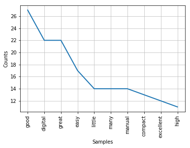

```python
fd.plot(10)
```

what does the word "easy" mean in this context?

NLTK can do the the reading for us!

```python
text=nltk.Text(product_reviews_1.words('Nikon_coolpix_4300.txt'))
text.concordance('easy',width=120,lines=25)
```

```
Displaying 22 of 22 matches:
d all day without bother . operating its many features is easy and often obvious - i ' m no annie lebovitz , but i was a
ction and production model reviews were positive . it ' s easy to use , and yet very feature rich . in the auto mode it
basically as a point and click , the scene modes are very easy to use and produce good results . the manual mode is feat
bought canon powershot s400 . reason for two ? it was not easy sharing one with my teen age kid . the two cameras are ve
ode is also working great . the 4300 comes with excellent easy to install software i use it on xp and win98 without prob
amera is perfect . touchups , redeye , and so on are very easy to alter , and correct . i definately recommend a large m
and canon models . the nikon coolpix 4300 is wonderful -- easy to use , high quality , and compact in size . with an ext
d very few bad ones . it takes excellent pics and is very easy to use , if you read the manual . if you cant get great p
 elses is too . downloads are a snap and quick . controls easy yo use and easy to get to . i ' m extremely glad i bought
downloads are a snap and quick . controls easy yo use and easy to get to . i ' m extremely glad i bought this camera . r
 am quite impressed with the features that it has . it is easy enough to use for a beginner like me but it has plenty of
his camera has , much less than many other models ! it is easy to " focus " in on the drawbacks , so do n ' t think i ha
xcellent macro shots as well . the menus and features are easy to manipulate and access , and it takes silent movies . i
and hard to find . great camera . i am impressed with how easy this camera is to use . it takes great pictures . the man
amera is to use . it takes great pictures . the manual is easy to understand , and it is mostly idiot proof . it is smal
 nikon definitely delivers a huge bang for the buck . its easy to use and the sheer fun of being able to use an array of
 , and this one had everything i was looking for . it ' s easy for beginners to use , but has features that more serious
atures an amatuer photo - enthusiast would want . 2 it is easy enough for my grandmother to use . 3 it is very compact b
ut the controls are so well designed that they ' re still easy to use . 4 it has optional lenses like wide angles and ex
 " digital film " it uses compact flash cards , which are easy to find , cheap , reliable and supported by many other de
thing period , really . this camera was affordable , very easy to learn , and produces spectacular images . the auto - m
 for the money if you ' re looking for something that ' s easy to use , small good for travel , and provides excellent ,
```

It seems like you are ready to produce some insights!!!

# Introducing the challenge

I'm the owner of a succesful online store through Amazon Australia and I hired you, a Marketing Research firm to analyse the reviews the customers are writing in Amazon for a particular set of products

[figure not shown]

# What we learned today...

NLTK easy as ABC

## A) Access and manipulate text

We accessed a default NLTK corpus

## B) Indentify syntactic elements

We used Part-of-speech tags to identify adjectives in the text.

## C) Extract information

We found some information about the context of the words we were analysing.

# If you use TEXT in your research, NLTK is relevant to you.

# Come to the next workshop and learn more!

https://research.unimelb.edu.au/infrastructure/research-platform-services/training/nltk